# Risk Factor Analysis

## Outcome Variable

**Outcome Variable:** haz

## Predictor Variables

**Intervention Variable:** feducyrs

**Adjustment Set:**

- arm
- W_mage
- meducyrs
- hhwealth_quart
- W_mhtcm
- single
- impsan
- W_gagebrth
- W_birthwt
- W_birthlen
- vagbrth
- parity
- delta_W_mage
- delta_meducyrs
- delta_hhwealth_quart
- delta_W_mhtcm
- delta_single
- delta_impsan
- delta_W_gagebrth
- delta_W_birthwt
- delta_W_birthlen
- delta_vagbrth
- delta_parity

## Stratifying Variables

The analysis was stratified on these variable(s):

- agecat
- studyid
- country

## Data Summary

| agecat | studyid | country | feducyrs | n_cell | n |
| --- | --- | --- | --- | --- | --- |
| 6 months | ki0047075b-MAL-ED | BANGLADESH | High | 50 | 132 |
| 6 months | ki0047075b-MAL-ED | BANGLADESH | Low | 36 | 132 |
| 6 months | ki0047075b-MAL-ED | BANGLADESH | Medium | 46 | 132 |
| 6 months | ki0047075b-MAL-ED | INDIA | High | 43 | 138 |
| 6 months | ki0047075b-MAL-ED | INDIA | Low | 54 | 138 |
| 6 months | ki0047075b-MAL-ED | INDIA | Medium | 41 | 138 |
| 6 months | ki0047075b-MAL-ED | NEPAL | High | 40 | 95 |
| 6 months | ki0047075b-MAL-ED | NEPAL | Low | 27 | 95 |
| 6 months | ki0047075b-MAL-ED | NEPAL | Medium | 28 | 95 |
| 6 months | ki0047075b-MAL-ED | PERU | High | 107 | 224 |
| 6 months | ki0047075b-MAL-ED | PERU | Low | 60 | 224 |
| 6 months | ki0047075b-MAL-ED | PERU | Medium | 57 | 224 |
| 6 months | ki0047075b-MAL-ED | SOUTH AFRICA | High | 33 | 92 |
| 6 months | ki0047075b-MAL-ED | SOUTH AFRICA | Low | 35 | 92 |
| 6 months | ki0047075b-MAL-ED | SOUTH AFRICA | Medium | 24 | 92 |
| 6 months | ki0047075b-MAL-ED | TANZANIA, UNITED REPUBLIC OF | High | 127 | 201 |
| 6 months | ki0047075b-MAL-ED | TANZANIA, UNITED REPUBLIC OF | Low | 55 | 201 |
| 6 months | ki0047075b-MAL-ED | TANZANIA, UNITED REPUBLIC OF | Medium | 19 | 201 |
| 6 months | ki1000304b-SAS-CompFeed | INDIA | High | 348 | 1333 |
| 6 months | ki1000304b-SAS-CompFeed | INDIA | Low | 550 | 1333 |
| 6 months | ki1000304b-SAS-CompFeed | INDIA | Medium | 435 | 1333 |
| 6 months | ki1000304b-SAS-FoodSuppl | INDIA | High | 101 | 380 |
| 6 months | ki1000304b-SAS-FoodSuppl | INDIA | Low | 132 | 380 |
| 6 months | ki1000304b-SAS-FoodSuppl | INDIA | Medium | 147 | 380 |
| 6 months | ki1017093b-PROVIDE | BANGLADESH | High | 203 | 583 |
| 6 months | ki1017093b-PROVIDE | BANGLADESH | Low | 201 | 583 |
| 6 months | ki1017093b-PROVIDE | BANGLADESH | Medium | 179 | 583 |
| 6 months | ki1017093c-NIH-Crypto | BANGLADESH | High | 279 | 715 |
| 6 months | ki1017093c-NIH-Crypto | BANGLADESH | Low | 223 | 715 |
| 6 months | ki1017093c-NIH-Crypto | BANGLADESH | Medium | 213 | 715 |

[output cut: 84 more lines]

The following strata were considered:

- agecat: 24 months, studyid: ki0047075b-MAL-ED, country: BANGLADESH
- agecat: 24 months, studyid: ki0047075b-MAL-ED, country: INDIA
- agecat: 24 months, studyid: ki0047075b-MAL-ED, country: NEPAL
- agecat: 24 months, studyid: ki0047075b-MAL-ED, country: PERU
- agecat: 24 months, studyid: ki0047075b-MAL-ED, country: SOUTH AFRICA
- agecat: 24 months, studyid: ki0047075b-MAL-ED, country: TANZANIA, UNITED REPUBLIC OF
- agecat: 24 months, studyid: ki1017093b-PROVIDE, country: BANGLADESH
- agecat: 24 months, studyid: ki1017093c-NIH-Crypto, country: BANGLADESH
- agecat: 24 months, studyid: ki1066203-TanzaniaChild2, country: TANZANIA, UNITED REPUBLIC OF
- agecat: 24 months, studyid: ki1113344-GMS-Nepal, country: NEPAL
- agecat: 24 months, studyid: ki1119695-PROBIT, country: BELARUS
- agecat: 24 months, studyid: ki1126311-ZVITAMBO, country: ZIMBABWE
- agecat: 24 months, studyid: ki1135781-COHORTS, country: GUATEMALA
- agecat: 24 months, studyid: ki1135781-COHORTS, country: INDIA
- agecat: 24 months, studyid: ki1135781-COHORTS, country: PHILIPPINES
- agecat: 24 months, studyid: ki1148112-LCNI-5, country: MALAWI
- agecat: 24 months, studyid: kiGH5241-JiVitA-3, country: BANGLADESH
- agecat: 24 months, studyid: kiGH5241-JiVitA-4, country: BANGLADESH
- agecat: 6 months, studyid: ki0047075b-MAL-ED, country: BANGLADESH
- agecat: 6 months, studyid: ki0047075b-MAL-ED, country: INDIA
- agecat: 6 months, studyid: ki0047075b-MAL-ED, country: NEPAL
- agecat: 6 months, studyid: ki0047075b-MAL-ED, country: PERU
- agecat: 6 months, studyid: ki0047075b-MAL-ED, country: SOUTH AFRICA
- agecat: 6 months, studyid: ki0047075b-MAL-ED, country: TANZANIA, UNITED REPUBLIC OF
- agecat: 6 months, studyid: ki1000304b-SAS-CompFeed, country: INDIA
- agecat: 6 months, studyid: ki1000304b-SAS-FoodSuppl, country: INDIA
- agecat: 6 months, studyid: ki1017093b-PROVIDE, country: BANGLADESH
- agecat: 6 months, studyid: ki1017093c-NIH-Crypto, country: BANGLADESH
- agecat: 6 months, studyid: ki1066203-TanzaniaChild2, country: TANZANIA, UNITED REPUBLIC OF
- agecat: 6 months, studyid: ki1113344-GMS-Nepal, country: NEPAL
- agecat: 6 months, studyid: ki1119695-PROBIT, country: BELARUS
- agecat: 6 months, studyid: ki1126311-ZVITAMBO, country: ZIMBABWE
- agecat: 6 months, studyid: ki1135781-COHORTS, country: GUATEMALA
- agecat: 6 months, studyid: ki1135781-COHORTS, country: INDIA
- agecat: 6 months, studyid: ki1135781-COHORTS, country: PHILIPPINES
- agecat: 6 months, studyid: ki1148112-LCNI-5, country: MALAWI
- agecat: 6 months, studyid: kiGH5241-JiVitA-3, country: BANGLADESH
- agecat: 6 months, studyid: kiGH5241-JiVitA-4, country: BANGLADESH

### Dropped Strata

Some strata were dropped due to rare outcomes:

- agecat: 24 months, studyid: ki1066203-TanzaniaChild2, country: TANZANIA, UNITED REPUBLIC OF

## Methods Detail

We’re interested in the causal parameters $E[Y_a]$ for all values of $a \in \mathcal{A}$. These parameters represent the mean outcome if, possibly contrary to fact, we intervened to set all units to have $A=a$. Under the randomization and positivity assumptions, these are identified by the statistical parameters $\psi_a=E_W[E_{Y|A,W}(Y|A=a,W)]$. In addition, we’re interested in the mean of $Y$, $E[Y]$ under no intervention (the observed mean). We will estimate these parameters by using SuperLearner to fit the relevant likelihood factors – $E_{Y|A,W}(Y|A=a,W)$ and $p(A=a|W)$, and then updating our likelihood fit using a joint TMLE.

For unadjusted analyses ($W=\{\}$), initial likelihoods were estimated using Lrnr_glm to estimate the simple $E(Y|A)$ and Lrnr_mean to estimate $p(A)$. For adjusted analyses, a small library containing Lrnr_glmnet, Lrnr_xgboost, and Lrnr_mean was used.

Having estimated these parameters, we will then use the delta method to estimate relative risks and attributable risks relative to a prespecified baseline level of $A$.

# Results Detail

## Results Plots

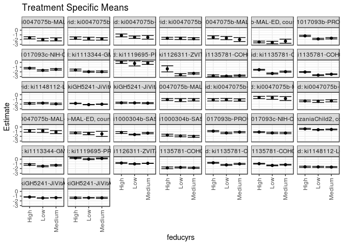

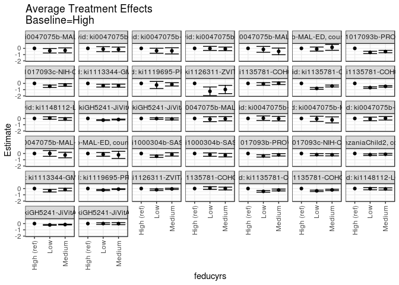

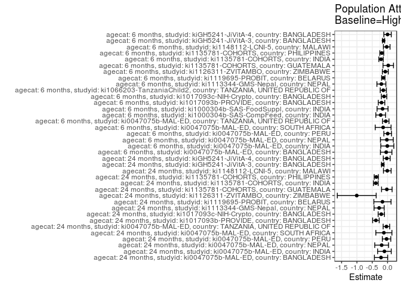

## Results Table

### Parameter: TSM

| agecat | studyid | country | intervention_level | baseline_level | estimate | ci_lower | ci_upper |
| --- | --- | --- | --- | --- | --- | --- | --- |
| 6 months | ki0047075b-MAL-ED | BANGLADESH | High | NA | -1.0352388 | -1.2487897 | -0.8216879 |
| 6 months | ki0047075b-MAL-ED | BANGLADESH | Low | NA | -1.1500415 | -1.4731457 | -0.8269373 |
| 6 months | ki0047075b-MAL-ED | BANGLADESH | Medium | NA | -1.0807578 | -1.3372902 | -0.8242254 |
| 6 months | ki0047075b-MAL-ED | INDIA | High | NA | -1.0876030 | -1.3345105 | -0.8406956 |
| 6 months | ki0047075b-MAL-ED | INDIA | Low | NA | -1.0493171 | -1.3111412 | -0.7874929 |
| 6 months | ki0047075b-MAL-ED | INDIA | Medium | NA | -1.1223233 | -1.3761622 | -0.8684844 |
| 6 months | ki0047075b-MAL-ED | NEPAL | High | NA | -0.5911512 | -0.8356193 | -0.3466831 |
| 6 months | ki0047075b-MAL-ED | NEPAL | Low | NA | -0.6509614 | -0.9812266 | -0.3206962 |
| 6 months | ki0047075b-MAL-ED | NEPAL | Medium | NA | -0.8203166 | -1.2390674 | -0.4015658 |
| 6 months | ki0047075b-MAL-ED | PERU | High | NA | -1.3278160 | -1.4998625 | -1.1557696 |
| 6 months | ki0047075b-MAL-ED | PERU | Low | NA | -1.4041284 | -1.6404762 | -1.1677807 |
| 6 months | ki0047075b-MAL-ED | PERU | Medium | NA | -1.2989756 | -1.5240666 | -1.0738846 |
| 6 months | ki0047075b-MAL-ED | SOUTH AFRICA | High | NA | -0.8395324 | -1.1399458 | -0.5391190 |
| 6 months | ki0047075b-MAL-ED | SOUTH AFRICA | Low | NA | -0.8311558 | -1.1798372 | -0.4824744 |
| 6 months | ki0047075b-MAL-ED | SOUTH AFRICA | Medium | NA | -1.0855498 | -1.4077455 | -0.7633541 |
| 6 months | ki0047075b-MAL-ED | TANZANIA, UNITED REPUBLIC OF | High | NA | -1.2596658 | -1.4322755 | -1.0870560 |
| 6 months | ki0047075b-MAL-ED | TANZANIA, UNITED REPUBLIC OF | Low | NA | -1.3918525 | -1.6450110 | -1.1386940 |
| 6 months | ki0047075b-MAL-ED | TANZANIA, UNITED REPUBLIC OF | Medium | NA | -1.4786508 | -2.0254353 | -0.9318662 |
| 6 months | ki1000304b-SAS-CompFeed | INDIA | High | NA | -1.1772039 | -1.3801595 | -0.9742484 |
| 6 months | ki1000304b-SAS-CompFeed | INDIA | Low | NA | -1.6122820 | -1.6958427 | -1.5287214 |
| 6 months | ki1000304b-SAS-CompFeed | INDIA | Medium | NA | -1.3168504 | -1.4520595 | -1.1816414 |
| 6 months | ki1000304b-SAS-FoodSuppl | INDIA | High | NA | -1.7358501 | -1.9365015 | -1.5351988 |
| 6 months | ki1000304b-SAS-FoodSuppl | INDIA | Low | NA | -1.9122035 | -2.0968415 | -1.7275656 |
| 6 months | ki1000304b-SAS-FoodSuppl | INDIA | Medium | NA | -2.0057988 | -2.1986713 | -1.8129263 |
| 6 months | ki1017093b-PROVIDE | BANGLADESH | High | NA | -0.8909034 | -1.0209572 | -0.7608496 |
| 6 months | ki1017093b-PROVIDE | BANGLADESH | Low | NA | -1.2751072 | -1.4139573 | -1.1362571 |
| 6 months | ki1017093b-PROVIDE | BANGLADESH | Medium | NA | -1.1022514 | -1.2367313 | -0.9677716 |
| 6 months | ki1017093c-NIH-Crypto | BANGLADESH | High | NA | -1.0846514 | -1.1939282 | -0.9753746 |
| 6 months | ki1017093c-NIH-Crypto | BANGLADESH | Low | NA | -1.2714169 | -1.4064588 | -1.1363749 |
| 6 months | ki1017093c-NIH-Crypto | BANGLADESH | Medium | NA | -1.2865808 | -1.4230121 | -1.1501494 |

[output cut: 81 more lines]

### Parameter: E(Y)

| agecat | studyid | country | intervention_level | baseline_level | estimate | ci_lower | ci_upper |
| --- | --- | --- | --- | --- | --- | --- | --- |
| 6 months | ki0047075b-MAL-ED | BANGLADESH | NA | NA | -1.0801894 | -1.2248166 | -0.9355622 |
| 6 months | ki0047075b-MAL-ED | INDIA | NA | NA | -1.0957005 | -1.2405754 | -0.9508256 |
| 6 months | ki0047075b-MAL-ED | NEPAL | NA | NA | -0.6134211 | -0.7965750 | -0.4302671 |
| 6 months | ki0047075b-MAL-ED | PERU | NA | NA | -1.3230208 | -1.4411177 | -1.2049240 |
| 6 months | ki0047075b-MAL-ED | SOUTH AFRICA | NA | NA | -0.9833877 | -1.1756113 | -0.7911640 |
| 6 months | ki0047075b-MAL-ED | TANZANIA, UNITED REPUBLIC OF | NA | NA | -1.3177032 | -1.4548809 | -1.1805254 |
| 6 months | ki1000304b-SAS-CompFeed | INDIA | NA | NA | -1.4006377 | -1.4802862 | -1.3209891 |
| 6 months | ki1000304b-SAS-FoodSuppl | INDIA | NA | NA | -1.8986842 | -2.0118892 | -1.7854792 |
| 6 months | ki1017093b-PROVIDE | BANGLADESH | NA | NA | -1.0871041 | -1.1635539 | -1.0106543 |
| 6 months | ki1017093c-NIH-Crypto | BANGLADESH | NA | NA | -1.1986783 | -1.2700937 | -1.1272630 |
| 6 months | ki1066203-TanzaniaChild2 | TANZANIA, UNITED REPUBLIC OF | NA | NA | -0.5442042 | -0.5932639 | -0.4951446 |
| 6 months | ki1113344-GMS-Nepal | NEPAL | NA | NA | -1.3338820 | -1.4121646 | -1.2555993 |
| 6 months | ki1119695-PROBIT | BELARUS | NA | NA | 0.1181349 | 0.0244298 | 0.2118400 |
| 6 months | ki1126311-ZVITAMBO | ZIMBABWE | NA | NA | -0.8840215 | -0.9103442 | -0.8576988 |
| 6 months | ki1135781-COHORTS | GUATEMALA | NA | NA | -1.8074115 | -1.8776669 | -1.7371562 |
| 6 months | ki1135781-COHORTS | INDIA | NA | NA | -0.9755018 | -1.0332483 | -0.9177553 |
| 6 months | ki1135781-COHORTS | PHILIPPINES | NA | NA | -1.1419345 | -1.1847445 | -1.0991244 |
| 6 months | ki1148112-LCNI-5 | MALAWI | NA | NA | -1.6442734 | -1.7137349 | -1.5748119 |
| 6 months | kiGH5241-JiVitA-3 | BANGLADESH | NA | NA | -1.3073109 | -1.3309979 | -1.2836240 |
| 6 months | kiGH5241-JiVitA-4 | BANGLADESH | NA | NA | -1.3498252 | -1.3977574 | -1.3018930 |
| 24 months | ki0047075b-MAL-ED | BANGLADESH | NA | NA | -1.8419658 | -1.9985654 | -1.6853663 |
| 24 months | ki0047075b-MAL-ED | INDIA | NA | NA | -1.7871970 | -1.9519446 | -1.6224494 |
| 24 months | ki0047075b-MAL-ED | NEPAL | NA | NA | -1.3050000 | -1.4938380 | -1.1161620 |
| 24 months | ki0047075b-MAL-ED | PERU | NA | NA | -1.7560976 | -1.8841319 | -1.6280632 |
| 24 months | ki0047075b-MAL-ED | SOUTH AFRICA | NA | NA | -1.6331868 | -1.8397539 | -1.4266197 |
| 24 months | ki0047075b-MAL-ED | TANZANIA, UNITED REPUBLIC OF | NA | NA | -2.5456780 | -2.6911200 | -2.4002359 |
| 24 months | ki1017093b-PROVIDE | BANGLADESH | NA | NA | -1.5861179 | -1.6693668 | -1.5028689 |
| 24 months | ki1017093c-NIH-Crypto | BANGLADESH | NA | NA | -1.4295331 | -1.5127726 | -1.3462935 |
| 24 months | ki1113344-GMS-Nepal | NEPAL | NA | NA | -1.8850636 | -1.9697435 | -1.8003837 |
| 24 months | ki1119695-PROBIT | BELARUS | NA | NA | -0.1248692 | -0.4220079 | 0.1722694 |
| 24 months | ki1126311-ZVITAMBO | ZIMBABWE | NA | NA | -2.3650922 | -2.4839447 | -2.2462396 |
| 24 months | ki1135781-COHORTS | GUATEMALA | NA | NA | -2.8522915 | -2.9193797 | -2.7852032 |
| 24 months | ki1135781-COHORTS | INDIA | NA | NA | -1.9321014 | -1.9930806 | -1.8711223 |
| 24 months | ki1135781-COHORTS | PHILIPPINES | NA | NA | -2.4020743 | -2.4479290 | -2.3562197 |
| 24 months | ki1148112-LCNI-5 | MALAWI | NA | NA | -1.8678984 | -1.9495904 | -1.7862065 |
| 24 months | kiGH5241-JiVitA-3 | BANGLADESH | NA | NA | -2.0060871 | -2.0338879 | -1.9782862 |
| 24 months | kiGH5241-JiVitA-4 | BANGLADESH | NA | NA | -1.7501299 | -1.7959342 | -1.7043256 |

### Parameter: ATE

| agecat | studyid | country | intervention_level | baseline_level | estimate | ci_lower | ci_upper |
| --- | --- | --- | --- | --- | --- | --- | --- |
| 6 months | ki0047075b-MAL-ED | BANGLADESH | High | High | 0.0000000 | 0.0000000 | 0.0000000 |
| 6 months | ki0047075b-MAL-ED | BANGLADESH | Low | High | -0.1148027 | -0.5043362 | 0.2747308 |
| 6 months | ki0047075b-MAL-ED | BANGLADESH | Medium | High | -0.0455190 | -0.3850967 | 0.2940587 |
| 6 months | ki0047075b-MAL-ED | INDIA | High | High | 0.0000000 | 0.0000000 | 0.0000000 |
| 6 months | ki0047075b-MAL-ED | INDIA | Low | High | 0.0382860 | -0.3222000 | 0.3987720 |
| 6 months | ki0047075b-MAL-ED | INDIA | Medium | High | -0.0347203 | -0.3903932 | 0.3209526 |
| 6 months | ki0047075b-MAL-ED | NEPAL | High | High | 0.0000000 | 0.0000000 | 0.0000000 |
| 6 months | ki0047075b-MAL-ED | NEPAL | Low | High | -0.0598102 | -0.4742290 | 0.3546086 |
| 6 months | ki0047075b-MAL-ED | NEPAL | Medium | High | -0.2291655 | -0.7125879 | 0.2542569 |
| 6 months | ki0047075b-MAL-ED | PERU | High | High | 0.0000000 | 0.0000000 | 0.0000000 |
| 6 months | ki0047075b-MAL-ED | PERU | Low | High | -0.0763124 | -0.3692899 | 0.2166652 |
| 6 months | ki0047075b-MAL-ED | PERU | Medium | High | 0.0288405 | -0.2543856 | 0.3120666 |
| 6 months | ki0047075b-MAL-ED | SOUTH AFRICA | High | High | 0.0000000 | 0.0000000 | 0.0000000 |
| 6 months | ki0047075b-MAL-ED | SOUTH AFRICA | Low | High | 0.0083766 | -0.4527573 | 0.4695104 |
| 6 months | ki0047075b-MAL-ED | SOUTH AFRICA | Medium | High | -0.2460174 | -0.6868448 | 0.1948099 |
| 6 months | ki0047075b-MAL-ED | TANZANIA, UNITED REPUBLIC OF | High | High | 0.0000000 | 0.0000000 | 0.0000000 |
| 6 months | ki0047075b-MAL-ED | TANZANIA, UNITED REPUBLIC OF | Low | High | -0.1321867 | -0.4385233 | 0.1741498 |
| 6 months | ki0047075b-MAL-ED | TANZANIA, UNITED REPUBLIC OF | Medium | High | -0.2189850 | -0.7918275 | 0.3538575 |
| 6 months | ki1000304b-SAS-CompFeed | INDIA | High | High | 0.0000000 | 0.0000000 | 0.0000000 |
| 6 months | ki1000304b-SAS-CompFeed | INDIA | Low | High | -0.4350781 | -0.6225453 | -0.2476109 |
| 6 months | ki1000304b-SAS-CompFeed | INDIA | Medium | High | -0.1396465 | -0.4099368 | 0.1306438 |
| 6 months | ki1000304b-SAS-FoodSuppl | INDIA | High | High | 0.0000000 | 0.0000000 | 0.0000000 |
| 6 months | ki1000304b-SAS-FoodSuppl | INDIA | Low | High | -0.1763534 | -0.4483501 | 0.0956433 |
| 6 months | ki1000304b-SAS-FoodSuppl | INDIA | Medium | High | -0.2699487 | -0.5499569 | 0.0100595 |
| 6 months | ki1017093b-PROVIDE | BANGLADESH | High | High | 0.0000000 | 0.0000000 | 0.0000000 |
| 6 months | ki1017093b-PROVIDE | BANGLADESH | Low | High | -0.3842038 | -0.5747921 | -0.1936155 |
| 6 months | ki1017093b-PROVIDE | BANGLADESH | Medium | High | -0.2113481 | -0.3985404 | -0.0241558 |
| 6 months | ki1017093c-NIH-Crypto | BANGLADESH | High | High | 0.0000000 | 0.0000000 | 0.0000000 |
| 6 months | ki1017093c-NIH-Crypto | BANGLADESH | Low | High | -0.1867654 | -0.3594047 | -0.0141261 |
| 6 months | ki1017093c-NIH-Crypto | BANGLADESH | Medium | High | -0.2019293 | -0.3757187 | -0.0281399 |

[output cut: 81 more lines]

### Parameter: PAR

| agecat | studyid | country | intervention_level | baseline_level | estimate | ci_lower | ci_upper |
| --- | --- | --- | --- | --- | --- | --- | --- |
| 6 months | ki0047075b-MAL-ED | BANGLADESH | High | NA | -0.0449506 | -0.2323880 | 0.1424868 |
| 6 months | ki0047075b-MAL-ED | INDIA | High | NA | -0.0080974 | -0.2208184 | 0.2046235 |
| 6 months | ki0047075b-MAL-ED | NEPAL | High | NA | -0.0222699 | -0.2319380 | 0.1873982 |
| 6 months | ki0047075b-MAL-ED | PERU | High | NA | 0.0047952 | -0.1200553 | 0.1296457 |
| 6 months | ki0047075b-MAL-ED | SOUTH AFRICA | High | NA | -0.1438553 | -0.4027633 | 0.1150527 |
| 6 months | ki0047075b-MAL-ED | TANZANIA, UNITED REPUBLIC OF | High | NA | -0.0580374 | -0.1630315 | 0.0469567 |
| 6 months | ki1000304b-SAS-CompFeed | INDIA | High | NA | -0.2234337 | -0.3826353 | -0.0642322 |
| 6 months | ki1000304b-SAS-FoodSuppl | INDIA | High | NA | -0.1628341 | -0.3423879 | 0.0167197 |
| 6 months | ki1017093b-PROVIDE | BANGLADESH | High | NA | -0.1962007 | -0.3021102 | -0.0902912 |
| 6 months | ki1017093c-NIH-Crypto | BANGLADESH | High | NA | -0.1140269 | -0.2010524 | -0.0270013 |
| 6 months | ki1066203-TanzaniaChild2 | TANZANIA, UNITED REPUBLIC OF | High | NA | -0.1391993 | -0.2380426 | -0.0403560 |
| 6 months | ki1113344-GMS-Nepal | NEPAL | High | NA | -0.2012581 | -0.3473557 | -0.0551606 |
| 6 months | ki1119695-PROBIT | BELARUS | High | NA | -0.1385891 | -0.1941500 | -0.0830281 |
| 6 months | ki1126311-ZVITAMBO | ZIMBABWE | High | NA | -0.0732559 | -0.1700051 | 0.0234932 |
| 6 months | ki1135781-COHORTS | GUATEMALA | High | NA | 0.0232287 | -0.1476471 | 0.1941045 |
| 6 months | ki1135781-COHORTS | INDIA | High | NA | -0.2123273 | -0.2840000 | -0.1406546 |
| 6 months | ki1135781-COHORTS | PHILIPPINES | High | NA | -0.1880833 | -0.2521768 | -0.1239899 |
| 6 months | ki1148112-LCNI-5 | MALAWI | High | NA | -0.0274301 | -0.1357378 | 0.0808776 |
| 6 months | kiGH5241-JiVitA-3 | BANGLADESH | High | NA | -0.1302282 | -0.1657265 | -0.0947298 |
| 6 months | kiGH5241-JiVitA-4 | BANGLADESH | High | NA | 0.0002166 | -0.1205253 | 0.1209586 |
| 24 months | ki0047075b-MAL-ED | BANGLADESH | High | NA | -0.2128236 | -0.4293412 | 0.0036940 |
| 24 months | ki0047075b-MAL-ED | INDIA | High | NA | -0.1017509 | -0.3237018 | 0.1201999 |
| 24 months | ki0047075b-MAL-ED | NEPAL | High | NA | -0.1920573 | -0.4178362 | 0.0337216 |
| 24 months | ki0047075b-MAL-ED | PERU | High | NA | -0.0326549 | -0.1708181 | 0.1055084 |
| 24 months | ki0047075b-MAL-ED | SOUTH AFRICA | High | NA | -0.1197546 | -0.3821424 | 0.1426332 |
| 24 months | ki0047075b-MAL-ED | TANZANIA, UNITED REPUBLIC OF | High | NA | -0.0370072 | -0.1434700 | 0.0694556 |
| 24 months | ki1017093b-PROVIDE | BANGLADESH | High | NA | -0.3800129 | -0.4866455 | -0.2733804 |
| 24 months | ki1017093c-NIH-Crypto | BANGLADESH | High | NA | -0.2041505 | -0.3070585 | -0.1012425 |
| 24 months | ki1113344-GMS-Nepal | NEPAL | High | NA | -0.2750536 | -0.4405033 | -0.1096038 |
| 24 months | ki1119695-PROBIT | BELARUS | High | NA | -0.1663626 | -0.4472709 | 0.1145456 |
| 24 months | ki1126311-ZVITAMBO | ZIMBABWE | High | NA | -1.0056622 | -1.6400844 | -0.3712400 |
| 24 months | ki1135781-COHORTS | GUATEMALA | High | NA | -0.0236970 | -0.1959235 | 0.1485294 |
| 24 months | ki1135781-COHORTS | INDIA | High | NA | -0.3836603 | -0.4607856 | -0.3065349 |
| 24 months | ki1135781-COHORTS | PHILIPPINES | High | NA | -0.3672762 | -0.4358025 | -0.2987499 |
| 24 months | ki1148112-LCNI-5 | MALAWI | High | NA | -0.0086818 | -0.1342052 | 0.1168416 |
| 24 months | kiGH5241-JiVitA-3 | BANGLADESH | High | NA | -0.1573001 | -0.1985535 | -0.1160467 |
| 24 months | kiGH5241-JiVitA-4 | BANGLADESH | High | NA | -0.0267168 | -0.1391468 | 0.0857133 |